# [Portfolio] Sales Time Series 1

## Defining the Business Problem

HappyMoonVC is a Venture Capital (VC) firm.

Venture Capital is a class of investment fund focused in growth capital for medium sized companies which already possess a portfolio of customers as well as reveneu, but which still need to gain scale. VCs invest in Startups and young companies with high growth potential.

HappyMoonVC has already invested in a new promissing Startup called GoInRail.

GoInRail is an innovative transportation method which utilized jet propulsion technology to launch a drone-lie vehicle over rails (which maintain the drone charged with electricity), and thus transport people in high speed!

Now HappyMoonVC is analyzing an complementary business, an e-commerce platform capable of supplying goods for GoInRail's clients. The startup offers a touch-screen monitor inside the GoInRail which allows travelers to purchase while onboard, with the option to retrieve the goods in the station where they exit or to receive the goods at home.

(If you find this too futurist, know that it already exists in Japan's metro!)

To decide if the investment is worth HappyMoonVC must predict the sales volumes.

## Load Packages

```python
!pip install pmdarima
```

```
     |████████████████████████████████| 1.5MB 4.8MB/s
```

```python
# Deactivating the multiple warning messages produced by the newest versions of Pandas and Matplotlib.
import sys
import warnings
import matplotlib.cbook
if not sys.warnoptions:
    warnings.simplefilter("ignore")
warnings.simplefilter(action='ignore', category=FutureWarning)
warnings.filterwarnings("ignore", category=FutureWarning)
warnings.filterwarnings("ignore", category=matplotlib.cbook.mplDeprecation)

# Data manipulation imports
import numpy as np
import pandas as pd
import itertools
from pandas import Series
import holidays

# Data visualization imports
import matplotlib.pyplot as plt
import matplotlib as m
import seaborn as sns
import plotly as py
import plotly.express as px
import plotly.graph_objs as go
from plotly.offline import download_plotlyjs, init_notebook_mode, plot, iplot

# Predictive modeling imports
import statsmodels
import statsmodels.api as sm
import statsmodels.tsa.api as smt
import statsmodels.stats as sms
import pmdarima as pm
import scipy
import scipy.stats as scs
from statsmodels.graphics import tsaplots
from statsmodels.tsa.seasonal import seasonal_decompose
from statsmodels.tsa.stattools import adfuller
from statsmodels.tsa.arima_model import ARMA
from statsmodels.tsa.arima_model import ARIMA
from statsmodels.stats.stattools import jarque_bera
import fbprophet
from fbprophet import Prophet

# Metrics and model performance imports
import math
from math import sqrt
import sklearn
from sklearn.metrics import mean_squared_error

# Graphics formatting imports
m.rcParams['axes.labelsize'] = 14
m.rcParams['xtick.labelsize'] = 12
m.rcParams['ytick.labelsize'] = 12
m.rcParams['text.color'] = 'k'
from matplotlib.pylab import rcParams
rcParams['figure.figsize'] = 20,10
matplotlib.style.use('ggplot')
%matplotlib inline
```

## Data

The dataset used is available publicly in Tableau's website, and represents the historic sales from the startup in which HappyMoonVC is considering investing.

Dataset source: https://community.tableau.com/docs/DOC-1236

HappyMoonVC wants to analyze and predict all data the in the "technology" category

```python
# Load data
data = pd.read_csv('https://raw.githubusercontent.com/Matheus-Schmitz/Datasets/master/tableau_superstore_sales.csv')
```

```python
# Shape
data.shape
```

```
(9994, 21)
```

```python
# Columns
data.columns
```

```
Index(['Row ID', 'Order ID', 'Order Date', 'Ship Date', 'Ship Mode',
       'Customer ID', 'Customer Name', 'Segment', 'Country', 'City', 'State',
       'Postal Code', 'Region', 'Product ID', 'Category', 'Sub-Category',
       'Product Name', 'Sales', 'Quantity', 'Discount', 'Profit'],
      dtype='object')
```

## Exploratory Analysis

```python
# Visualizing data
data.head()
```

|  | Row ID | Order ID | Order Date | Ship Date | Ship Mode | Customer ID | Customer Name | Segment | Country | City | State | Postal Code | Region | Product ID | Category | Sub-Category | Product Name | Sales | Quantity | Discount | Profit |
| --- | --- | --- | --- | --- | --- | --- | --- | --- | --- | --- | --- | --- | --- | --- | --- | --- | --- | --- | --- | --- | --- |
| 0 | 1 | CA-2016-152156 | 2016-11-08 | 2016-11-11 | Second Class | CG-12520 | Claire Gute | Consumer | United States | Henderson | Kentucky | 42420 | South | FUR-BO-10001798 | Furniture | Bookcases | Bush Somerset Collection Bookcase | 261.9600 | 2 | 0.00 | 41.9136 |
| 1 | 2 | CA-2016-152156 | 2016-11-08 | 2016-11-11 | Second Class | CG-12520 | Claire Gute | Consumer | United States | Henderson | Kentucky | 42420 | South | FUR-CH-10000454 | Furniture | Chairs | Hon Deluxe Fabric Upholstered Stacking Chairs,... | 731.9400 | 3 | 0.00 | 219.5820 |
| 2 | 3 | CA-2016-138688 | 2016-06-12 | 2016-06-16 | Second Class | DV-13045 | Darrin Van Huff | Corporate | United States | Los Angeles | California | 90036 | West | OFF-LA-10000240 | Office Supplies | Labels | Self-Adhesive Address Labels for Typewriters b... | 14.6200 | 2 | 0.00 | 6.8714 |
| 3 | 4 | US-2015-108966 | 2015-10-11 | 2015-10-18 | Standard Class | SO-20335 | Sean O'Donnell | Consumer | United States | Fort Lauderdale | Florida | 33311 | South | FUR-TA-10000577 | Furniture | Tables | Bretford CR4500 Series Slim Rectangular Table | 957.5775 | 5 | 0.45 | -383.0310 |
| 4 | 5 | US-2015-108966 | 2015-10-11 | 2015-10-18 | Standard Class | SO-20335 | Sean O'Donnell | Consumer | United States | Fort Lauderdale | Florida | 33311 | South | OFF-ST-10000760 | Office Supplies | Storage | Eldon Fold 'N Roll Cart System | 22.3680 | 2 | 0.20 | 2.5164 |

```python
# Statistic summaries
data.describe()
```

|  | Row ID | Postal Code | Sales | Quantity | Discount | Profit |
| --- | --- | --- | --- | --- | --- | --- |
| count | 9994.000000 | 9994.000000 | 9994.000000 | 9994.000000 | 9994.000000 | 9994.000000 |
| mean | 4997.500000 | 55190.379428 | 229.858001 | 3.789574 | 0.156203 | 28.656896 |
| std | 2885.163629 | 32063.693350 | 623.245101 | 2.225110 | 0.206452 | 234.260108 |
| min | 1.000000 | 1040.000000 | 0.444000 | 1.000000 | 0.000000 | -6599.978000 |
| 25% | 2499.250000 | 23223.000000 | 17.280000 | 2.000000 | 0.000000 | 1.728750 |
| 50% | 4997.500000 | 56430.500000 | 54.490000 | 3.000000 | 0.200000 | 8.666500 |
| 75% | 7495.750000 | 90008.000000 | 209.940000 | 5.000000 | 0.200000 | 29.364000 |
| max | 9994.000000 | 99301.000000 | 22638.480000 | 14.000000 | 0.800000 | 8399.976000 |

```python
# Checking for missing values
data.info()
```

```
<class 'pandas.core.frame.DataFrame'>
RangeIndex: 9994 entries, 0 to 9993
Data columns (total 21 columns):
 #   Column         Non-Null Count  Dtype
---  ------         --------------  -----
 0   Row ID         9994 non-null   int64
 1   Order ID       9994 non-null   object
 2   Order Date     9994 non-null   object
 3   Ship Date      9994 non-null   object
 4   Ship Mode      9994 non-null   object
 5   Customer ID    9994 non-null   object
 6   Customer Name  9994 non-null   object
 7   Segment        9994 non-null   object
 8   Country        9994 non-null   object
 9   City           9994 non-null   object
 10  State          9994 non-null   object
 11  Postal Code    9994 non-null   int64
 12  Region         9994 non-null   object
 13  Product ID     9994 non-null   object
 14  Category       9994 non-null   object
 15  Sub-Category   9994 non-null   object
 16  Product Name   9994 non-null   object
 17  Sales          9994 non-null   float64
 18  Quantity       9994 non-null   int64
 19  Discount       9994 non-null   float64
 20  Profit         9994 non-null   float64
dtypes: float64(3), int64(3), object(15)
memory usage: 1.6+ MB
```

```python
# Setting column names to lowercase
data.columns = map(str.lower, data.columns)
```

```python
# Substituting espaces and dashes in the column names by underscores
data.columns = data.columns.str.replace(" ", "_")
data.columns = data.columns.str.replace("-", "_")
```

```python
# Checking
data.columns
```

```
Index(['row_id', 'order_id', 'order_date', 'ship_date', 'ship_mode',
       'customer_id', 'customer_name', 'segment', 'country', 'city', 'state',
       'postal_code', 'region', 'product_id', 'category', 'sub_category',
       'product_name', 'sales', 'quantity', 'discount', 'profit'],
      dtype='object')
```

```python
# Assess the unique values per column (to know whether a variable is categorical or not)
for c in data.columns:
    if len(set(data[c])) < 20:
        print(c,set(data[c]))
```

```
ship_mode {'Second Class', 'First Class', 'Same Day', 'Standard Class'}
segment {'Corporate', 'Home Office', 'Consumer'}
country {'United States'}
region {'Central', 'East', 'South', 'West'}
category {'Technology', 'Furniture', 'Office Supplies'}
sub_category {'Fasteners', 'Tables', 'Art', 'Phones', 'Bookcases', 'Machines', 'Copiers', 'Labels', 'Accessories', 'Supplies', 'Appliances', 'Envelopes', 'Paper', 'Furnishings', 'Binders', 'Storage', 'Chairs'}
quantity {1, 2, 3, 4, 5, 6, 7, 8, 9, 10, 11, 12, 13, 14}
discount {0.0, 0.8, 0.2, 0.3, 0.45, 0.5, 0.7, 0.6, 0.32, 0.1, 0.4, 0.15}
```

```python
# Splitting data by category
df_technology = data.loc[data['category'] == 'Technology']
df_furniture = data.loc[data['category'] == 'Furniture']
df_office = data.loc[data['category'] == 'Office Supplies']
```

```python
# Aggregating sales by order date
ts_technology = df_technology.groupby('order_date')['sales'].sum().reset_index()
ts_furniture = df_furniture.groupby('order_date')['sales'].sum().reset_index()
ts_office = df_office.groupby('order_date')['sales'].sum().reset_index()
```

```python
# Checking dataset
ts_technology
```

|  | order_date | sales |
| --- | --- | --- |
| 0 | 2014-01-06 | 1147.940 |
| 1 | 2014-01-09 | 31.200 |
| 2 | 2014-01-13 | 646.740 |
| 3 | 2014-01-15 | 149.950 |
| 4 | 2014-01-16 | 124.200 |
| ... | ... | ... |
| 819 | 2017-12-25 | 401.208 |
| 820 | 2017-12-27 | 164.388 |
| 821 | 2017-12-28 | 14.850 |
| 822 | 2017-12-29 | 302.376 |
| 823 | 2017-12-30 | 90.930 |

824 rows × 2 columns

```python
# Setting the date as index
ts_technology = ts_technology.set_index('order_date')
ts_furniture = ts_furniture.set_index('order_date')
ts_office = ts_office.set_index('order_date')
```

```python
# Visualizing the series
ts_technology
```

| order_date | sales |
| --- | --- |
| 2014-01-06 | 1147.940 |
| 2014-01-09 | 31.200 |
| 2014-01-13 | 646.740 |
| 2014-01-15 | 149.950 |
| 2014-01-16 | 124.200 |
| ... | ... |
| 2017-12-25 | 401.208 |
| 2017-12-27 | 164.388 |
| 2017-12-28 | 14.850 |
| 2017-12-29 | 302.376 |
| 2017-12-30 | 90.930 |

824 rows × 1 columns

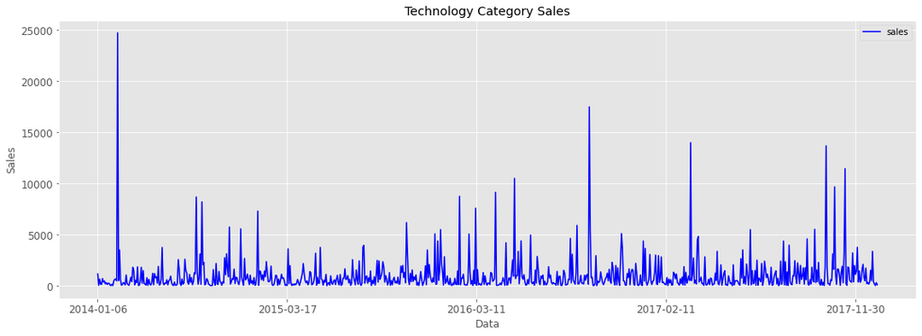

```python
# Plotting sales in the technology category
sales_technology = ts_technology[['sales']]
ax = sales_technology.plot(color = 'b', figsize = (18,6))
plt.xlabel("Data")
plt.ylabel('Sales')
plt.title("Technology Category Sales")
plt.show()
```

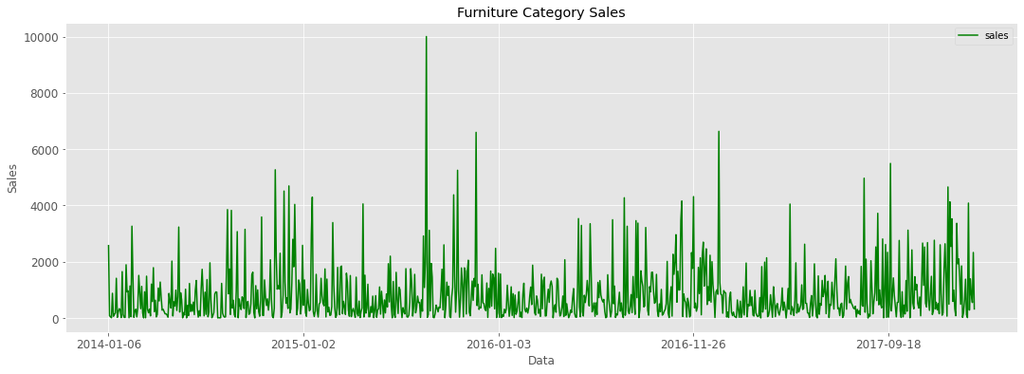

```python
# Plotting sales in the furniture category
sales_furniture = ts_furniture[['sales']]
ax = sales_furniture.plot(color = 'g', figsize = (18,6))
plt.xlabel("Data")
plt.ylabel('Sales')
plt.title("Furniture Category Sales")
plt.show()
```

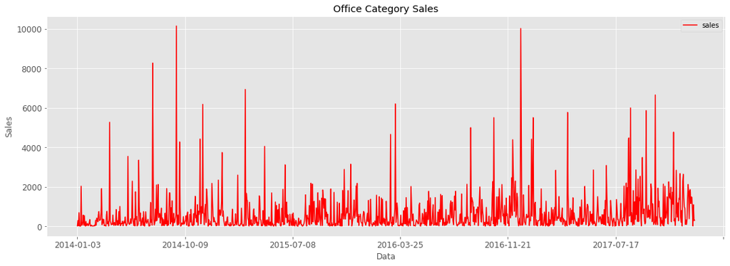

```python
# Plotting sales in the office category
sales_office = ts_office[['sales']]
ax = sales_office.plot(color = 'r', figsize = (18,6))
plt.xlabel("Data")
plt.ylabel('Sales')
plt.title("Office Category Sales")
plt.show()
```

Adjusting the index type to DateTimeIndex (which characterizes a time series), so that it's possible to aggregate monthly and obtain the mean monthly sales.

```python
# Checking index type
type(sales_technology.index)
```

```
pandas.core.indexes.base.Index
```

```python
# Changing index type
sales_technology.index = pd.to_datetime(sales_technology.index)
sales_furniture.index = pd.to_datetime(sales_furniture.index)
sales_office.index = pd.to_datetime(sales_office.index)
```

```python
# Checking index type
type(sales_technology.index)
```

```
pandas.core.indexes.datetimes.DatetimeIndex
```

```python
# Resampling data to a monthly frequency
# Done by setting the month as index and then calculating the mean of daily sales over the month
sales_technology_monthly_mean = sales_technology['sales'].resample('MS').mean()
sales_furniture_monthly_mean = sales_furniture['sales'].resample('MS').mean()
sales_office_monthly_mean = sales_office['sales'].resample('MS').mean()
```

```python
# Verifying the resulting type
type(sales_technology_monthly_mean)
```

```
pandas.core.series.Series
```

```python
# Checking the data
sales_technology_monthly_mean
```

```
order_date
2014-01-01     449.041429
2014-02-01     229.787143
2014-03-01    2031.948375
2014-04-01     613.028933
2014-05-01     564.698588
2014-06-01     766.905909
2014-07-01     533.608933
2014-08-01     708.435385
2014-09-01    2035.838133
2014-10-01     596.900900
2014-11-01    1208.056320
2014-12-01    1160.732889
2015-01-01     925.070800
2015-02-01     431.121250
2015-03-01     574.662333
2015-04-01     697.559500
2015-05-01     831.642857
2015-06-01     429.024400
2015-07-01     691.397733
2015-08-01    1108.902286
2015-09-01     950.856400
2015-10-01     594.716111
2015-11-01    1037.982652
2015-12-01    1619.637636
2016-01-01     374.671067
2016-02-01    1225.891400
2016-03-01    1135.150105
2016-04-01     875.911882
2016-05-01    1601.816167
2016-06-01    1023.259500
2016-07-01     829.312500
2016-08-01     483.620100
2016-09-01    1144.170300
2016-10-01    1970.835875
2016-11-01    1085.642360
2016-12-01     970.554870
2017-01-01    1195.218071
2017-02-01     430.501714
2017-03-01    1392.859250
2017-04-01     825.559133
2017-05-01     678.329400
2017-06-01     853.055000
2017-07-01    1054.996636
2017-08-01     978.842333
2017-09-01    1077.704120
2017-10-01    1493.439227
2017-11-01    1996.750920
2017-12-01     955.865652
Freq: MS, Name: sales, dtype: float64
```

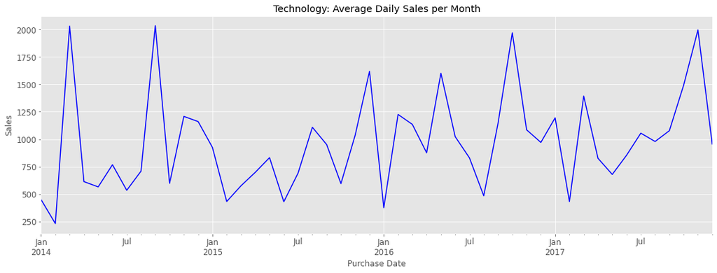

```python
# Plotting the monthly mean daily sales of technology products
sales_technology_monthly_mean.plot(figsize = (18, 6), color = 'blue')
plt.xlabel("Purchase Date")
plt.ylabel('Sales')
plt.title("Technology: Average Daily Sales per Month")
plt.show()
```

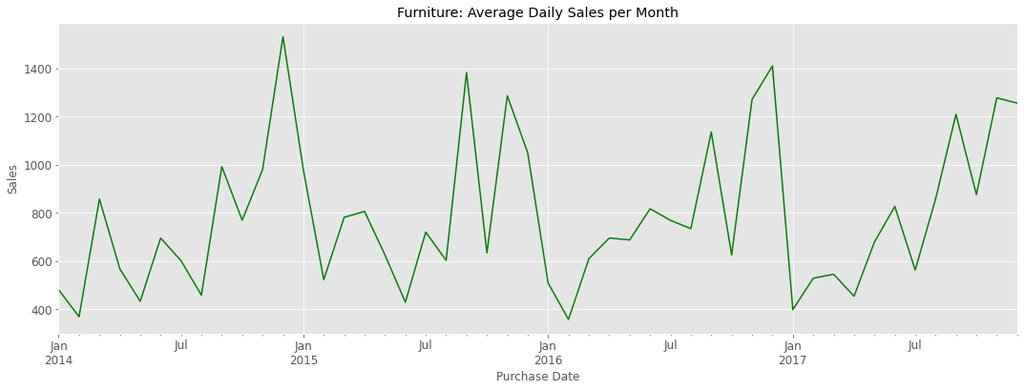

```python
# Plotting the monthly mean daily sales of furniture products
sales_furniture_monthly_mean.plot(figsize = (18, 6), color = 'green')
plt.xlabel("Purchase Date")
plt.ylabel('Sales')
plt.title("Furniture: Average Daily Sales per Month")
plt.show()
```

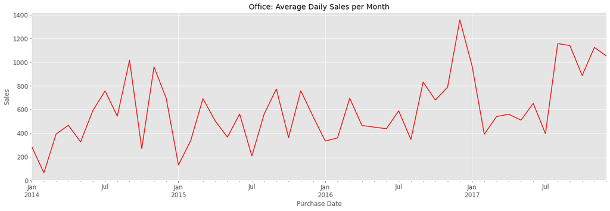

```python
# Plotting the monthly mean daily sales of office products
sales_office_monthly_mean.plot(figsize = (20, 6), color = 'red')
plt.xlabel("Purchase Date")
plt.ylabel('Sales')
plt.title("Office: Average Daily Sales per Month")
plt.show()
```

Decomposing the series to analyze its componentes.

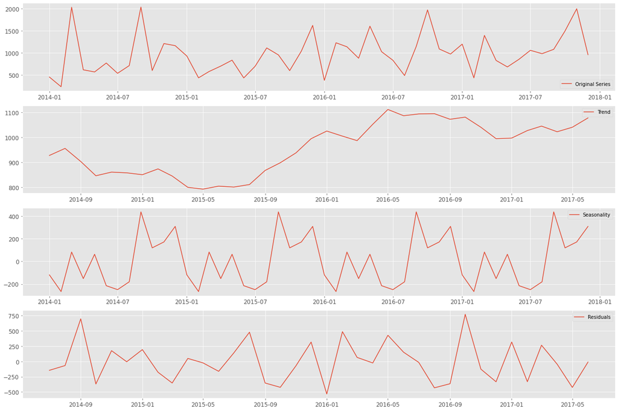

```python
# Decomposing the time series with the monthly mean daily sales of technology products
decomposition = seasonal_decompose(sales_technology_monthly_mean, freq = 12)
rcParams['figure.figsize'] = 18, 12

# Components
trend = decomposition.trend
seasonal = decomposition.seasonal
residual = decomposition.resid

# Plot
plt.subplot(411)
plt.plot(sales_technology_monthly_mean, label = 'Original Series')
plt.legend(loc = 'best')
plt.subplot(412)
plt.plot(trend, label = 'Trend')
plt.legend(loc = 'best')
plt.subplot(413)
plt.plot(seasonal, label = 'Seasonality')
plt.legend(loc = 'best')
plt.subplot(414)
plt.plot(residual, label = 'Residuals')
plt.legend(loc = 'best')
plt.tight_layout()
```

Stationarity test:

```python
# Function to test stationarity
def stationarity_test(serie):

    # Calculating moving statistics
    rolmean = serie.rolling(window = 12).mean()
    rolstd = serie.rolling(window = 12).std()

    # Plot of moving statistics
    orig = plt.plot(serie, color = 'blue', label = 'Original')
    mean = plt.plot(rolmean, color = 'red', label = 'Moving Average')
    std = plt.plot(rolstd, color = 'black', label = 'Standard Deviation')
    plt.legend(loc = 'best')
    plt.title('Moving Statistics - Mean and Standard Deviation')
    plt.show()

    # Dickey-Fuller test:
    # Print
    print('\nDickey-Fuller Test Result:\n')

    # Test
    dftest = adfuller(serie, autolag = 'AIC')

    # Formatting the output
    df_output = pd.Series(dftest[0:4], index = ['Test Statistic',
                                               'P-value',
                                               'Number of Lags Considered',
                                               'Number of Observations Used'])

    # Loop through each item in the test output
    for key, value in dftest[4].items():
        df_output['Critical Value (%s)'%key] = value

    # Print
    print (df_output)

    # Testing p-value
    print ('\nConclusion:')
    if df_output[1] > 0.05:
        print('\nThe p-value is above 0.05, therefore there are no evidences to reject the null hypothesis.')
        print('This series probably is not stationary.')
    else:
        print('\nThe p-value is below 0.05, therefore there are evidences to reject the null hypothesis.')
        print('This series probably is stationary.')
```

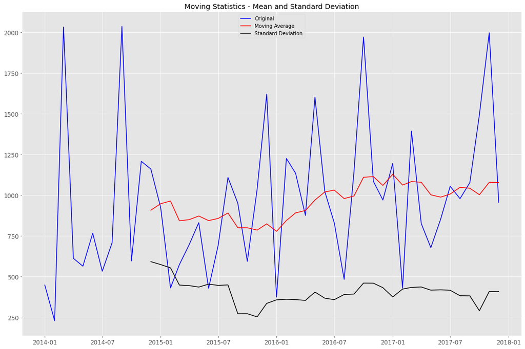

```
Dickey-Fuller Test Result:

Test Statistic                -7.187969e+00
P-value                        2.547334e-10
Number of Lags Considered      0.000000e+00
Number of Observations Used    4.700000e+01
Critical Value (1%)           -3.577848e+00
Critical Value (5%)           -2.925338e+00
Critical Value (10%)          -2.600774e+00
dtype: float64

Conclusion:

The p-value is below 0.05, therefore there are evidences to reject the null hypothesis.
This series probably is stationary.
```

```python
# Verifying if the series is stationary
stationarity_test(sales_technology_monthly_mean)
```

## Function to Calculate Accuracy

```python
# Function
def performance(y_true, y_pred):
    mse = ((y_pred - y_true) ** 2).mean()
    mape = np.mean(np.abs((y_true - y_pred) / y_true)) * 100
    return( print('The prediction MSE is {}'.format(round(mse, 2))+
                  '\nThe prediction RMSE is {}'.format(round(np.sqrt(mse), 2))+
                  '\nThe prediction MAPE is {}'.format(round(mape, 2))))
```

## ARMA Model

```python
# Load data
data = pd.read_csv('https://raw.githubusercontent.com/dsacademybr/Datasets/master/dataset6.csv')

# Setting column names to lowercase
data.columns = map(str.lower, data.columns)

# Substituting espaces and dashes in the column names by underscores
data.columns = data.columns.str.replace(" ", "_")
data.columns = data.columns.str.replace("-", "_")

# Splitting data by category
df_technology = data.loc[data['category'] == 'Technology']

# Aggregating sales by order date
ts_technology = df_technology.groupby('order_date')['sales'].sum().reset_index()

# Setting the date as index
ts_technology = ts_technology.set_index('order_date')

# Retrieving only sales data
sales_technology = ts_technology[['sales']]

# Changing index type
sales_technology.index = pd.to_datetime(sales_technology.index)

# Resampling data to a monthly frequency
# Done by setting the month as index and then calculating the mean of daily sales over the month
sales_technology_monthly_mean = sales_technology['sales'].resample('MS').mean()

# Train-Test Split
X = sales_technology_monthly_mean
train_size = int(len(X) * 0.75)
trainset, testset = X[0:train_size], X[train_size:]
```

https://www.statsmodels.org/stable/generated/statsmodels.tsa.arima_model.ARMA.html

```python
# Seeking the best values for the 'p' and 'q' parameters
# The goal is the lowest possible AIC

# Initial values
best_aic = np.inf
best_order = None
best_model = None

# Values to be used in seeking the best combination, order = (i, j)
test_order_values = [1, 2, 3, 4, 5]

# Loop
for i in test_order_values:
    for j in test_order_values:
        try:
            tmp_mdl = ARMA(trainset, order = (i, j)).fit(disp = False)
            tmp_aic = tmp_mdl.aic
            if tmp_aic < best_aic:
                best_aic = tmp_aic
                best_order = (i, j)
                best_model = tmp_mdl
        except: continue

# Print
print('\nBest AIC Score: %6.2f | order: %s'%(best_aic, best_order))
print('\nBest Model:', best_model.summary())
```

[output not shown]

```
Best AIC Score: 552.92 | order: (3, 1)

Best Model:                               ARMA Model Results
==============================================================================
Dep. Variable:                  sales   No. Observations:                   36
Model:                     ARMA(3, 1)   Log Likelihood                -270.459
Method:                       css-mle   S.D. of innovations            442.123
Date:                Sat, 09 May 2020   AIC                            552.918
Time:                        17:27:13   BIC                            562.420
Sample:                    01-01-2014   HQIC                           556.235
                         - 12-01-2016
===============================================================================
                  coef    std err          z      P>|z|      [0.025      0.975]
-------------------------------------------------------------------------------
const         939.5686     63.228     14.860      0.000     815.644    1063.493
ar.L1.sales    -0.3149      0.770     -0.409      0.685      -1.824       1.194
ar.L2.sales    -0.2023      0.207     -0.979      0.335      -0.607       0.203
ar.L3.sales     0.1073      0.260      0.413      0.682      -0.402       0.616
ma.L1.sales     0.1991      0.759      0.262      0.795      -1.289       1.687
                                    Roots
=============================================================================
                  Real          Imaginary           Modulus         Frequency
-----------------------------------------------------------------------------
AR.1           -0.8027           -1.4232j            1.6340           -0.3317
AR.2           -0.8027           +1.4232j            1.6340            0.3317
AR.3            3.4918           -0.0000j            3.4918           -0.0000
MA.1           -5.0226           +0.0000j            5.0226            0.5000
-----------------------------------------------------------------------------
```

The warning messages above indicate taht for some order combinations (i, j) the model could not converge. The combination with the best performance was: order = (3, 1)

```python
# Create model
arma_model = ARMA(trainset, order = (3, 1))
```

```python
# Train model
arma_model_fit = arma_model.fit(method = 'mle', disp = False)
```

```python
# Model summary
arma_model_fit.summary()
```

ARMA Model Results

| Dep. Variable: | sales | No. Observations: | 36 |
| --- | --- | --- | --- |
| Model: | ARMA(3, 1) | Log Likelihood | -270.459 |
| Method: | mle | S.D. of innovations | 442.123 |
| Date: | Sat, 09 May 2020 | AIC | 552.918 |
| Time: | 17:27:13 | BIC | 562.420 |
| Sample: | 01-01-2014 | HQIC | 556.235 |
|  | - 12-01-2016 |  |  |

|  | coef | std err | z | P>\|z\| | [0.025 | 0.975] |
| --- | --- | --- | --- | --- | --- | --- |
| const | 939.5857 | 63.229 | 14.860 | 0.000 | 815.660 | 1063.512 |
| ar.L1.sales | -0.3149 | 0.770 | -0.409 | 0.685 | -1.824 | 1.194 |
| ar.L2.sales | -0.2023 | 0.207 | -0.979 | 0.335 | -0.607 | 0.203 |
| ar.L3.sales | 0.1073 | 0.260 | 0.413 | 0.682 | -0.402 | 0.616 |
| ma.L1.sales | 0.1991 | 0.759 | 0.262 | 0.795 | -1.289 | 1.687 |

Roots

|  | Real | Imaginary | Modulus | Frequency |
| --- | --- | --- | --- | --- |
| AR.1 | -0.8027 | -1.4232j | 1.6340 | -0.3317 |
| AR.2 | -0.8027 | +1.4232j | 1.6340 | 0.3317 |
| AR.3 | 3.4917 | -0.0000j | 3.4917 | -0.0000 |
| MA.1 | -5.0228 | +0.0000j | 5.0228 | 0.5000 |

Evaluating based on the AIC (Akaike Information Criterion) metric. The lower the value the better the model performance.

```python
# Model predictions
arma_predict = arma_model_fit.predict(start = pd.to_datetime('2017-01-01'),
                                       end = pd.to_datetime('2017-12-01'),
                                       dynamic = False)
```

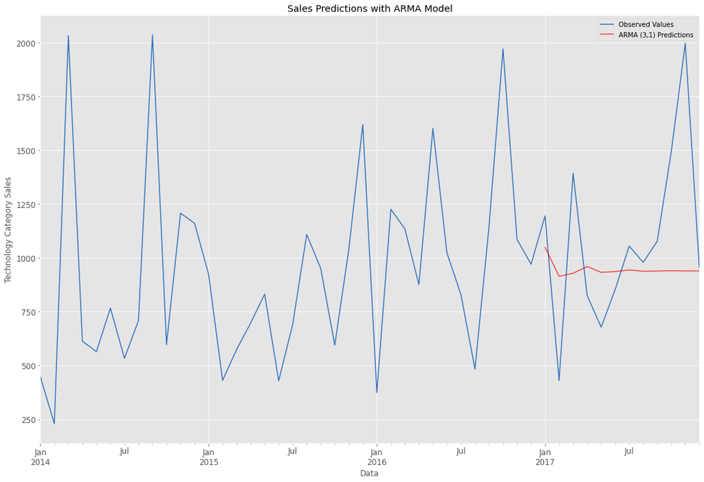

```python
# Plotting predictions
ax = sales_technology_monthly_mean.plot(label = 'Observed Values', color = '#3574BF')
rcParams['figure.figsize'] = 18, 8
arma_predict.plot(ax = ax, label = 'ARMA (3,1) Predictions', alpha = 0.7, color = 'red')
plt.title('Sales Predictions with ARMA Model')
plt.xlabel('Data')
plt.ylabel('Technology Category Sales')
plt.legend()
plt.show()
```

```python
# Evaluating performance with test data
arma_results = performance(testset, arma_predict)
arma_results
```

```
The prediction MSE is 168192.9
The prediction RMSE is 410.11
The prediction MAPE is 28.4
```

Creating a function to plot various diagnostic metrics which can be used to assess the model

```python
# Function
def tsplot(y, lags = None, figsize = (12, 8), style = 'bmh'):

    # If the series isn't from type pd.Series, convert it
    if not isinstance(y, pd.Series):
        y = pd.Series(y)

    # Creating plots
    with plt.style.context(style):
        fig = plt.figure(figsize = figsize)
        layout = (3, 2)
        ts_ax = plt.subplot2grid(layout, (0, 0), colspan = 2)
        acf_ax = plt.subplot2grid(layout, (1, 0))
        pacf_ax = plt.subplot2grid(layout, (1, 1))
        qq_ax = plt.subplot2grid(layout, (2, 0))
        pp_ax = plt.subplot2grid(layout, (2, 1))

        y.plot(ax = ts_ax)
        ts_ax.set_title('Plots for Time Series Analysis')
        smt.graphics.plot_acf(y, lags = lags, ax = acf_ax, alpha = 0.05)
        smt.graphics.plot_pacf(y, lags = lags, ax = pacf_ax, alpha = 0.05)
        sm.qqplot(y, line = 's', ax = qq_ax)
        qq_ax.set_title('QQ Plot')
        scs.probplot(y, sparams = (y.mean(), y.std()), plot = pp_ax)

        plt.tight_layout()
    return
```

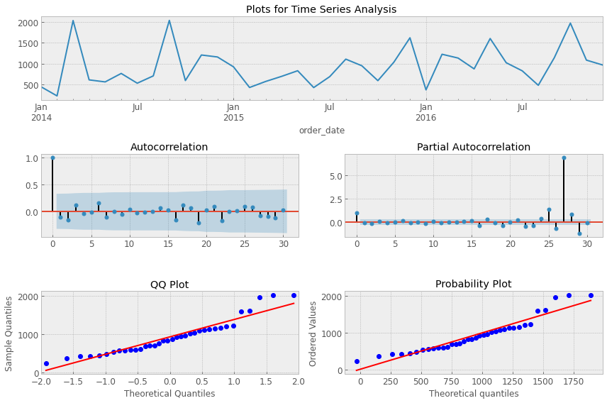

```python
# Running the functions with train data
tsplot(trainset, lags = 30)
```

The model's rediduals must be normally distributed. Checking with the jarque_bera test.

```python
# Test
score, pvalue, _, _ = jarque_bera(arma_model_fit.resid)

# Result
if pvalue < 0.05:
    print ('\nThe residuals might not be normally distributed.')
else:
    print ('\nThe residuals appear to be normally distributed.')
```

```
The residuals appear to be normally distributed.
```

```python
# Ljung-Box test
ljungbox_test = sms.diagnostic.acorr_ljungbox(arma_model_fit.resid, lags = [30], boxpierce = False)
print('P-value =', ljungbox_test[1])
```

```
P-value = [0.9105266]
```

The p-value is greater than 0.05, which indicates that the residual are independent with a 95% confidence, thefore an (3, 1) ARMA model has a good fit.

## ARIMA Model

```python
# Load data
data = pd.read_csv('https://raw.githubusercontent.com/dsacademybr/Datasets/master/dataset6.csv')

# Setting column names to lowercase
data.columns = map(str.lower, data.columns)

# Substituting espaces and dashes in the column names by underscores
data.columns = data.columns.str.replace(" ", "_")
data.columns = data.columns.str.replace("-", "_")

# Splitting data by category
df_technology = data.loc[data['category'] == 'Technology']

# Aggregating sales by order date
ts_technology = df_technology.groupby('order_date')['sales'].sum().reset_index()

# Setting the date as index
ts_technology = ts_technology.set_index('order_date')

# Retrieving only sales data
sales_technology = ts_technology[['sales']]

# Changing index type
sales_technology.index = pd.to_datetime(sales_technology.index)

# Resampling data to a monthly frequency
# Done by setting the month as index and then calculating the mean of daily sales over the month
sales_technology_monthly_mean = sales_technology['sales'].resample('MS').mean()

# Train-Test Split
X = sales_technology_monthly_mean
train_size = int(len(X) * 0.75)
trainset, testset = X[0:train_size], X[train_size:]
```

```python
# Function to evaluate an ARIMA model
def evaluate_arima_model(X, arima_order):

    # Prepare data
    train_size = int(len(X) * 0.75)
    train, test = X[0:train_size], X[train_size:]
    history = [x for x in train]

    # predict
    predictions = list()

    # Loop
    for t in range(len(test)):
        model = ARIMA(history, order = arima_order)
        model_fit = model.fit(method = 'mle', disp = 0)
        yhat = model_fit.forecast()[0]
        predictions.append(yhat)
        history.append(test[t])

    # Calculate model error
    error = mean_squared_error(test, predictions)
    return error
```

```python
# Finding the optimal combination of 'p', 'd' and 'q' values for the ARIMA model
def find_best_arima(dataset, p_values, d_values, q_values):

    # Adjusting the data type
    dataset = dataset.astype('float32')

    # Defining control variables
    best_score, best_cfg = float("inf"), None

    # Loop through 'p d q' values
    for p in p_values:
        for d in d_values:
            for q in q_values:
                order = (p,d,q)
                try:
                    mse = evaluate_arima_model(dataset, order)
                    if mse < best_score:
                        best_score, best_cfg = mse, order
                    print('ARIMA%s MSE = %.3f' % (order, mse))
                except:
                    continue

    print('\nBest Model ARIMA%s MSE = %.3f' % (best_cfg, best_score))
```

```python
# Set values to loop through
p_values = [0, 2, 4, 6]
d_values = [0, 2, 4, 6]
q_values = [0, 2, 4, 6]
```

```python
# Applying function to seek the best values for 'p d q'
find_best_arima(sales_technology_monthly_mean.values, p_values, d_values, q_values)
```

```
ARIMA(0, 0, 0) MSE = 174155.275
ARIMA(0, 0, 2) MSE = 191647.549
ARIMA(0, 0, 4) MSE = 194995.823
```

```
ARIMA(0, 0, 6) MSE = 173741.615
ARIMA(0, 2, 0) MSE = 793878.683
ARIMA(2, 0, 0) MSE = 194636.248
ARIMA(2, 2, 0) MSE = 299872.253
ARIMA(4, 0, 0) MSE = 188135.157
```

```
ARIMA(4, 0, 2) MSE = 201385.415
```

[output not shown]

```
ARIMA(4, 0, 4) MSE = 205003.913
ARIMA(4, 2, 0) MSE = 299179.994
ARIMA(6, 0, 0) MSE = 204155.758
```

```
ARIMA(6, 0, 2) MSE = 183004.507
```

[output not shown]

```
ARIMA(6, 0, 4) MSE = 140567.260

Best Model ARIMA(6, 0, 4) MSE = 140567.260
```

```
/usr/local/lib/python3.6/dist-packages/statsmodels/base/model.py:492: HessianInversionWarning:

Inverting hessian failed, no bse or cov_params available
```

The warning messages above indicate that some of the combinations cannot create a model which converges.

According to the result the optimal values are: oreder = (6, 0, 4).

```python
# Create model
arima_model = ARIMA(trainset, order = (6,0,4))
```

```python
# Train model
arima_model_fit = arima_model.fit(method = 'mle', disp = False)
```

```python
# Model summary
arima_model_fit.summary()
```

ARMA Model Results

| Dep. Variable: | sales | No. Observations: | 36 |
| --- | --- | --- | --- |
| Model: | ARMA(6, 4) | Log Likelihood | -268.327 |
| Method: | mle | S.D. of innovations | 383.392 |
| Date: | Sat, 09 May 2020 | AIC | 560.655 |
| Time: | 17:29:10 | BIC | 579.657 |
| Sample: | 01-01-2014 | HQIC | 567.287 |
|  | - 12-01-2016 |  |  |

|  | coef | std err | z | P>\|z\| | [0.025 | 0.975] |
| --- | --- | --- | --- | --- | --- | --- |
| const | 939.1474 | 64.124 | 14.646 | 0.000 | 813.467 | 1064.828 |
| ar.L1.sales | -0.6945 | 0.216 | -3.213 | 0.004 | -1.118 | -0.271 |
| ar.L2.sales | -0.1558 | 0.316 | -0.493 | 0.627 | -0.775 | 0.464 |
| ar.L3.sales | -0.6355 | 0.308 | -2.062 | 0.050 | -1.240 | -0.031 |
| ar.L4.sales | -0.7980 | 0.290 | -2.750 | 0.011 | -1.367 | -0.229 |
| ar.L5.sales | -0.1525 | 0.275 | -0.554 | 0.584 | -0.692 | 0.387 |
| ar.L6.sales | 0.1194 | 0.203 | 0.589 | 0.561 | -0.278 | 0.516 |
| ma.L1.sales | 0.6915 | 0.279 | 2.477 | 0.020 | 0.144 | 1.239 |
| ma.L2.sales | -0.1103 | 0.264 | -0.418 | 0.680 | -0.628 | 0.407 |
| ma.L3.sales | 0.6915 | 0.212 | 3.268 | 0.003 | 0.277 | 1.106 |
| ma.L4.sales | 1.0000 | 0.272 | 3.672 | 0.001 | 0.466 | 1.534 |

Roots

|  | Real | Imaginary | Modulus | Frequency |
| --- | --- | --- | --- | --- |
| AR.1 | 0.5448 | -0.8690j | 1.0257 | -0.1609 |
| AR.2 | 0.5448 | +0.8690j | 1.0257 | 0.1609 |
| AR.3 | -1.0291 | -0.7452j | 1.2705 | -0.4003 |
| AR.4 | -1.0291 | +0.7452j | 1.2705 | 0.4003 |
| AR.5 | -1.3659 | -0.0000j | 1.3659 | -0.5000 |
| AR.6 | 3.6119 | -0.0000j | 3.6119 | -0.0000 |
| MA.1 | 0.5738 | -0.8190j | 1.0000 | -0.1527 |
| MA.2 | 0.5738 | +0.8190j | 1.0000 | 0.1527 |
| MA.3 | -0.9195 | -0.3931j | 1.0000 | -0.4357 |
| MA.4 | -0.9195 | +0.3931j | 1.0000 | 0.4357 |

Evaluating based on the AIC (Akaike Information Criterion) metric. The lower the value the better the model performance.

```python
# Model predictions
arima_predict = arima_model_fit.predict(start = pd.to_datetime('2017-01-01'),
                                         end = pd.to_datetime('2017-12-01'),
                                         dynamic = False)
```

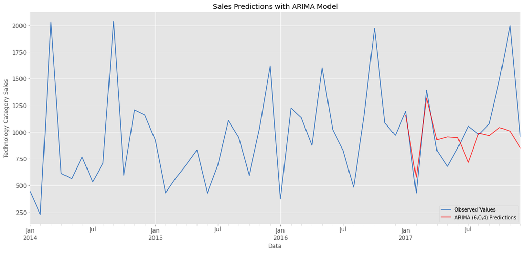

```python
# Plotting predictions
ax = sales_technology_monthly_mean.plot(label = 'Observed Values', color = '#3574BF')
rcParams['figure.figsize'] = 14, 7
arima_predict.plot(ax = ax, label = 'ARIMA (6,0,4) Predictions', alpha = 0.8, color = 'red')
plt.title('Sales Predictions with ARIMA Model')
plt.xlabel('Data')
plt.ylabel('Technology Category Sales')
plt.legend()
plt.show()
```

```python
# Calculating performance
arima_results = performance(testset, arima_predict)
arima_results
```

```
The prediction MSE is 120137.97
The prediction RMSE is 346.61
The prediction MAPE is 20.1
```

The model's rediduals must be normally distributed. Checking with the jarque_bera test..

```python
# Test
score, pvalue, _, _ = jarque_bera(arima_model_fit.resid)

# Result
if pvalue < 0.05:
    print ('\nThe residuals might not be normally distributed.')
else:
    print ('\nThe residuals appear to be normally distributed.')
```

```
The residuals appear to be normally distributed.
```

```python
# Ljung-Box test
ljungbox_test = sms.diagnostic.acorr_ljungbox(arima_model_fit.resid, lags = [30], boxpierce = False)
print('P-value =', ljungbox_test[1])
```

```
P-value = [0.92902243]
```

Model comparison:

**ARMA (3,1):**

> - The prediction MSE is 168192.9
> - The prediction RMSE is 410.11
> - The prediction MAPE is 28.4

**ARIMA (6,0,4):**

> - The prediction MSE is 120137.97
> - The prediction RMSE is 346.61
> - The prediction MAPE is 20.1

## SARIMA Model

### Grid Search Method 1 - auto_arima

Using an Auto-Arima model to find the best order hiperparameters for the lowest AIC score.

```python
# Load data
data = pd.read_csv('https://raw.githubusercontent.com/dsacademybr/Datasets/master/dataset6.csv')

# Setting column names to lowercase
data.columns = map(str.lower, data.columns)

# Substituting espaces and dashes in the column names by underscores
data.columns = data.columns.str.replace(" ", "_")
data.columns = data.columns.str.replace("-", "_")

# Splitting data by category
df_technology = data.loc[data['category'] == 'Technology']

# Aggregating sales by order date
ts_technology = df_technology.groupby('order_date')['sales'].sum().reset_index()

# Setting the date as index
ts_technology = ts_technology.set_index('order_date')

# Retrieving only sales data
sales_technology = ts_technology[['sales']]

# Changing index type
sales_technology.index = pd.to_datetime(sales_technology.index)

# Resampling data to a monthly frequency
# Done by setting the month as index and then calculating the mean of daily sales over the month
sales_technology_monthly_mean = sales_technology['sales'].resample('MS').mean()

# Train-Test Split
X = sales_technology_monthly_mean
train_size = int(len(X) * 0.75)
trainset, testset = X[0:train_size], X[train_size:]
```

```python
# Searching for the ideal model order
# Using pm.auto_arima method to apply a Grid Search and retrieve the best model
sarima_hiperparameters = pm.auto_arima(trainset,
                          seasonal = True,
                          m = 12,
                          d = 0,
                          D = 1,
                          max_p = 2,
                          max_q = 2,
                          trace = True,
                          error_action = 'ignore',
                          suppress_warnings = True)
```

```
Performing stepwise search to minimize aic
Fit ARIMA(2,0,2)x(1,1,1,12) [intercept=True]; AIC=nan, BIC=nan, Time=nan seconds
Fit ARIMA(0,0,0)x(0,1,0,12) [intercept=True]; AIC=380.244, BIC=382.600, Time=0.024 seconds
Fit ARIMA(1,0,0)x(1,1,0,12) [intercept=True]; AIC=378.184, BIC=382.897, Time=0.495 seconds
Fit ARIMA(0,0,1)x(0,1,1,12) [intercept=True]; AIC=nan, BIC=nan, Time=nan seconds
Fit ARIMA(0,0,0)x(0,1,0,12) [intercept=False]; AIC=378.609, BIC=379.787, Time=0.015 seconds
Fit ARIMA(1,0,0)x(0,1,0,12) [intercept=True]; AIC=382.218, BIC=385.753, Time=0.068 seconds
Fit ARIMA(1,0,0)x(2,1,0,12) [intercept=True]; AIC=nan, BIC=nan, Time=nan seconds
Fit ARIMA(1,0,0)x(1,1,1,12) [intercept=True]; AIC=nan, BIC=nan, Time=nan seconds
Fit ARIMA(1,0,0)x(0,1,1,12) [intercept=True]; AIC=nan, BIC=nan, Time=nan seconds
Fit ARIMA(1,0,0)x(2,1,1,12) [intercept=True]; AIC=nan, BIC=nan, Time=nan seconds
Fit ARIMA(0,0,0)x(1,1,0,12) [intercept=True]; AIC=377.369, BIC=380.903, Time=0.331 seconds
Fit ARIMA(0,0,0)x(2,1,0,12) [intercept=True]; AIC=nan, BIC=nan, Time=nan seconds
Fit ARIMA(0,0,0)x(1,1,1,12) [intercept=True]; AIC=nan, BIC=nan, Time=nan seconds
Fit ARIMA(0,0,0)x(0,1,1,12) [intercept=True]; AIC=nan, BIC=nan, Time=nan seconds
Fit ARIMA(0,0,0)x(2,1,1,12) [intercept=True]; AIC=nan, BIC=nan, Time=nan seconds
Fit ARIMA(0,0,1)x(1,1,0,12) [intercept=True]; AIC=376.797, BIC=381.509, Time=0.255 seconds
Fit ARIMA(0,0,1)x(0,1,0,12) [intercept=True]; AIC=382.184, BIC=385.718, Time=0.145 seconds
Fit ARIMA(0,0,1)x(2,1,0,12) [intercept=True]; AIC=nan, BIC=nan, Time=nan seconds
Fit ARIMA(0,0,1)x(1,1,1,12) [intercept=True]; AIC=nan, BIC=nan, Time=nan seconds
Fit ARIMA(0,0,1)x(2,1,1,12) [intercept=True]; AIC=nan, BIC=nan, Time=nan seconds
Fit ARIMA(1,0,1)x(1,1,0,12) [intercept=True]; AIC=378.567, BIC=384.458, Time=0.472 seconds
Fit ARIMA(0,0,2)x(1,1,0,12) [intercept=True]; AIC=378.319, BIC=384.209, Time=0.330 seconds
Fit ARIMA(1,0,2)x(1,1,0,12) [intercept=True]; AIC=379.996, BIC=387.065, Time=0.518 seconds
Total fit time: 2.702 seconds
```

Analyzing the results from the Stepwise Grid Search the best model is:

```python
# Print summary of the model with best parameters
print(sarima_hiperparameters.summary())
```

```
                                 Statespace Model Results
==========================================================================================
Dep. Variable:                                  y   No. Observations:                   36
Model:             SARIMAX(0, 0, 1)x(1, 1, 0, 12)   Log Likelihood                -184.398
Date:                            Sat, 09 May 2020   AIC                            376.797
Time:                                    17:29:14   BIC                            381.509
Sample:                                         0   HQIC                           378.047
                                             - 36
Covariance Type:                              opg
==============================================================================
                 coef    std err          z      P>|z|      [0.025      0.975]
------------------------------------------------------------------------------
intercept    163.5162     74.251      2.202      0.028      17.986     309.046
ma.L1         -0.4516      0.232     -1.948      0.051      -0.906       0.003
ar.S.L12      -0.7046      0.146     -4.812      0.000      -0.992      -0.418
sigma2      2.449e+05   1.09e+05      2.253      0.024    3.19e+04    4.58e+05
===================================================================================
Ljung-Box (Q):                         nan   Jarque-Bera (JB):                 0.65
Prob(Q):                               nan   Prob(JB):                         0.72
Heteroskedasticity (H):               2.44   Skew:                             0.13
Prob(H) (two-sided):                  0.23   Kurtosis:                         2.24
===================================================================================

Warnings:
[1] Covariance matrix calculated using the outer product of gradients (complex-step).
```

https://www.statsmodels.org/dev/generated/statsmodels.tsa.statespace.sarimax.SARIMAX.html

```python
# Create SARIMA model
sarima_model_v1 = sm.tsa.statespace.SARIMAX(trainset,
                                             order = (0, 0, 1),
                                             seasonal_order = (1, 1, 0, 12),
                                             enforce_stationarity = False,
                                             enforce_invertibility = False)
```

```python
# Training (fit) model
sarima_model_v1_fit = sarima_model_v1.fit()
```